# DATA 608 HW 1

**Principles of Data Visualization and Introduction to ggplot2**

I have provided you with data about the 5,000 fastest growing companies in the US, as compiled by Inc. magazine. lets read this in:

```r
library(dplyr)
```

```r
library(ggplot2)
inc <- read.csv("https://raw.githubusercontent.com/charleyferrari/CUNY_DATA_608/master/module1/Data/inc5000_data.csv", header= TRUE)
```

And lets preview this data:

```r
head(inc)
```

```
##   Rank                         Name Growth_Rate   Revenue
## 1    1                         Fuhu      421.48 1.179e+08
## 2    2        FederalConference.com      248.31 4.960e+07
## 3    3                The HCI Group      245.45 2.550e+07
## 4    4                      Bridger      233.08 1.900e+09
## 5    5                       DataXu      213.37 8.700e+07
## 6    6 MileStone Community Builders      179.38 4.570e+07
##                       Industry Employees         City State
## 1 Consumer Products & Services       104   El Segundo    CA
## 2          Government Services        51     Dumfries    VA
## 3                       Health       132 Jacksonville    FL
## 4                       Energy        50      Addison    TX
## 5      Advertising & Marketing       220       Boston    MA
## 6                  Real Estate        63       Austin    TX
```

```r
summary(inc)
```

```
##       Rank          Name            Growth_Rate         Revenue
##  Min.   :   1   Length:5001        Min.   :  0.340   Min.   :2.000e+06
##  1st Qu.:1252   Class :character   1st Qu.:  0.770   1st Qu.:5.100e+06
##  Median :2502   Mode  :character   Median :  1.420   Median :1.090e+07
##  Mean   :2502                      Mean   :  4.612   Mean   :4.822e+07
##  3rd Qu.:3751                      3rd Qu.:  3.290   3rd Qu.:2.860e+07
##  Max.   :5000                      Max.   :421.480   Max.   :1.010e+10
##
##    Industry           Employees           City              State
##  Length:5001        Min.   :    1.0   Length:5001        Length:5001
##  Class :character   1st Qu.:   25.0   Class :character   Class :character
##  Mode  :character   Median :   53.0   Mode  :character   Mode  :character
##                     Mean   :  232.7
##                     3rd Qu.:  132.0
##                     Max.   :66803.0
##                     NA's   :12
```

Think a bit on what these summaries mean. Use the space below to add some more relevant non-visual exploratory information you think helps you understand this data:

I like the dplyr function ‘glimpse’. It allows me to see the df dimensions, class of variables and more rows than head by default.

```r
glimpse(inc)
```

```
## Rows: 5,001
## Columns: 8
## $ Rank        <int> 1, 2, 3, 4, 5, 6, 7, 8, 9, 10, 11, 12, 13, 14, 15, 16, 17,…
## $ Name        <chr> "Fuhu", "FederalConference.com", "The HCI Group", "Bridger…
## $ Growth_Rate <dbl> 421.48, 248.31, 245.45, 233.08, 213.37, 179.38, 174.04, 17…
## $ Revenue     <dbl> 1.179e+08, 4.960e+07, 2.550e+07, 1.900e+09, 8.700e+07, 4.5…
## $ Industry    <chr> "Consumer Products & Services", "Government Services", "He…
## $ Employees   <int> 104, 51, 132, 50, 220, 63, 27, 75, 97, 15, 149, 165, 250, …
## $ City        <chr> "El Segundo", "Dumfries", "Jacksonville", "Addison", "Bost…
## $ State       <chr> "CA", "VA", "FL", "TX", "MA", "TX", "TN", "CA", "UT", "RI"…
```

I also would like to get some counts on the categorical columns

It looks like California has the largest number of companies on the list.

```r
count(inc, State)
```

```
##    State   n
## 1     AK   2
## 2     AL  51
## 3     AR   9
## 4     AZ 100
## 5     CA 701
## 6     CO 134
## 7     CT  50
## 8     DC  43
## 9     DE  16
## 10    FL 282
## 11    GA 212
## 12    HI   7
## 13    IA  28
## 14    ID  17
```

[output cut: 38 more lines]

It looks like IT Services is the most common industry on the list.

```r
count(inc, Industry)
```

```
##                        Industry   n
## 1       Advertising & Marketing 471
## 2  Business Products & Services 482
## 3             Computer Hardware  44
## 4                  Construction 187
## 5  Consumer Products & Services 203
## 6                     Education  83
## 7                        Energy 109
## 8                   Engineering  74
## 9        Environmental Services  51
## 10           Financial Services 260
## 11              Food & Beverage 131
## 12          Government Services 202
## 13                       Health 355
## 14              Human Resources 196
## 15                    Insurance  50
## 16                  IT Services 733
## 17   Logistics & Transportation 155
## 18                Manufacturing 256
## 19                        Media  54
## 20                  Real Estate  96
## 21                       Retail 203
## 22                     Security  73
## 23                     Software 342
## 24           Telecommunications 129
## 25         Travel & Hospitality  62
```

## Question 1

Create a graph that shows the distribution of companies in the dataset by State (ie how many are in each state). There are a lot of States, so consider which axis you should use. This visualization is ultimately going to be consumed on a ‘portrait’ oriented screen (ie taller than wide), which should further guide your layout choices.

I put the states on the y axis due to the number of states and ‘portrait’ orientation. Due to the number of bars I thought about removing the background lines but decided that they make it easier to evaluate the unordered bars.. I thought about ordering the states by count but decided that leaving them in alphabetical order will make it easier to find an individual state.

```r
temp <- count(inc, State) %>% as.data.frame()
```

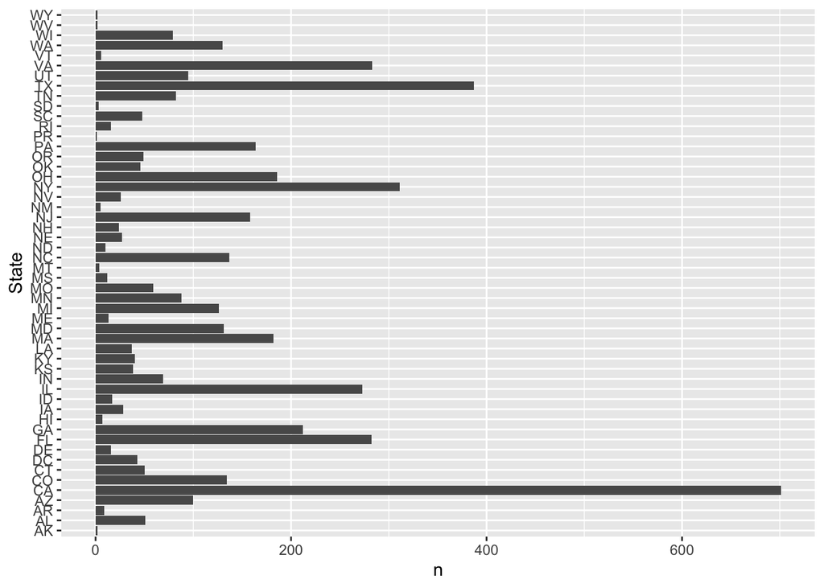

```r
ggplot2::ggplot(data = temp, aes(y=State, x=n)) + geom_bar(stat='identity')
```

## Quesiton 2

Lets dig in on the state with the 3rd most companies in the data set. Imagine you work for the state and are interested in how many people are employed by companies in different industries. Create a plot that shows the average and/or median employment by industry for companies in this state (only use cases with full data, use R’s `complete.cases()` function.) In addition to this, your graph should show how variable the ranges are, and you should deal with outliers.

I ended up log transforming the number of employees otherwise the plot would be unreadable.

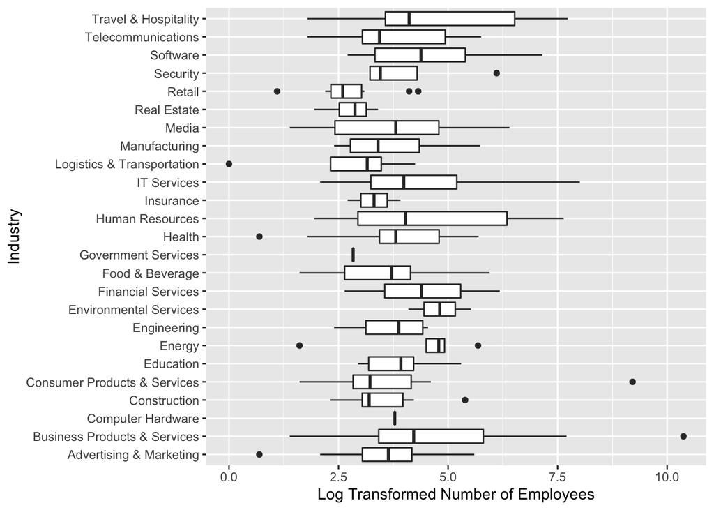

```r
temp2 <- inc %>% filter(State=='NY'& complete.cases(.) == TRUE)

ggplot2::ggplot(temp2, aes(y=Industry, x=log(Employees))) + geom_boxplot() + xlab("Log Transformed Number of Employees")
```

## Question 3

Now imagine you work for an investor and want to see which industries generate the most revenue per employee. Create a chart that makes this information clear. Once again, the distribution per industry should be shown.

I’m assuming question 3 is for all states, not just NY. I calculated the revenue per employee and then log transformed that value to deal with outliers.

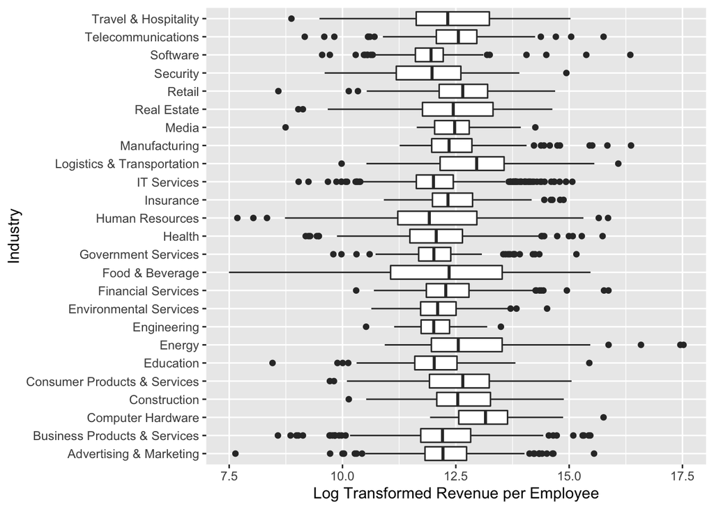

```r
temp3 <- inc %>% mutate(per_employee = Revenue/Employees)

ggplot2::ggplot(temp3, aes(y=Industry, x=log(per_employee))) + geom_boxplot() + xlab("Log Transformed Revenue per Employee")
```